# Data Joins + Pivots

## Monday, April 20

Today we will…

- Big Picture
- New Material
  - Joining data with `dplyr`
  - Pivoting data with `tidyr`
- PA 4: Military Spending

**Follow along**

Remember to download, save, and open up the handout for this week! This week you need to download and save some data as well.

# Big Picture - Data Science Workflow

## Data Science Process

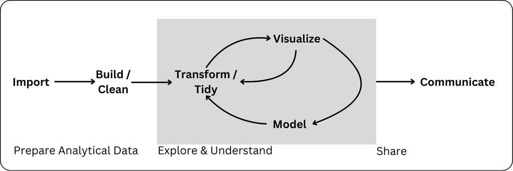

Adapted from [r4ds](https://r4ds.hadley.nz/intro#fig-ds-diagram)

## We have covered…

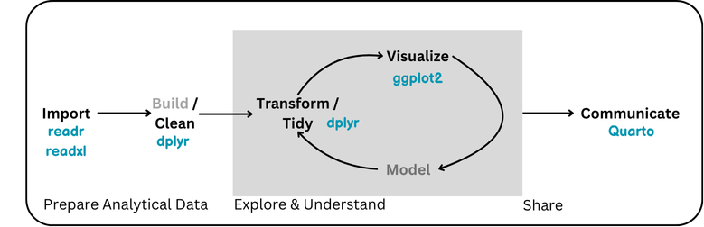

## Today

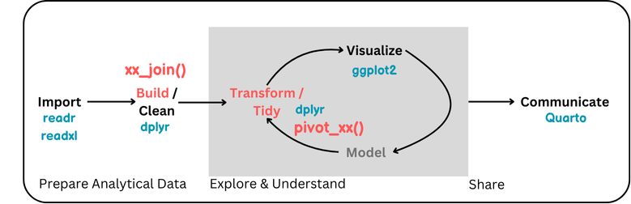

# Building an Analytical Dataset

## Getting Data

- So far, we have simply needed to import *one* nice *rectangular* data set in a *typical* file type
- Real life often gets a bit more complicated!!

## Motivating (Real) Example<sup>1</sup>

- Texas Education Data (AEIS): K-12 student performance data provided by the Texas Education Agency
- Provides A LOT of information … in [many separate files](https://rptsvr1.tea.texas.gov/perfreport/aeis/2005/xplore/DownloadSelData.html):
  - by year
  - for State, Regions, Districts, or Schools
  - for different sets of variables

🧐 need to get this #%$ together before we can analyze it

[^1]: I worked with this data for a project. See the [paper](https://educationaldatamining.org/edm2024/proceedings/2024.EDM-short-papers.52/2024.EDM-short-papers.52.pdf) and [Github repo](https://github.com/manncz/aeis-aux-rct/) if you are interested!

## Relational Data

- Multiple, interconnected tables of data are called **relational**.
- Individual datsets may not provide exactly what we need - but we can use the *relation* between datasets to get the information we want.

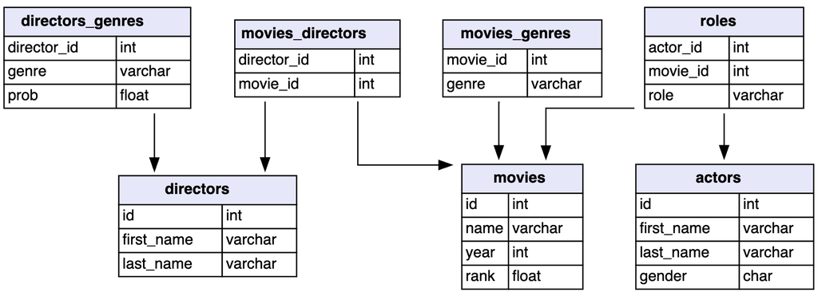

IMDb movie relational data

## Example - IMDb Movie Data

**Discussion**

What if we want to know which actor has worked with the most directors in the dataset?

What **analytical dataset** would we need to answer this question? What are the rows, and variables needed?

- 💡 In order to answer our question, we need to **combine** some of the individual datasets into one big dataset
- **Joins!**

# Data Joins

## Data Joins

We can **combine** (join) data tables based on their relations.

**Mutating joins**

Add *variables* from a new dataframe to observations in an existing dataframe.

`full_join()`, `left_join()`, `right_join()`, `inner_join()`

**Filtering Joins**

Filter *observations* based on values in new dataframe.

`semi_join()`, `anti_join()`

## Keys

Some combination of variables (should) uniquely identify an observation in a data set.

- To combine (join) two datasets, a **key** needs to be present in both.

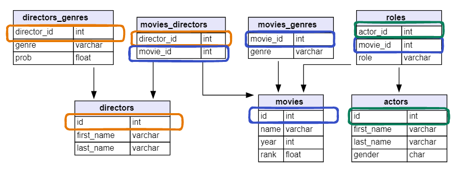

## General Structure of a Join

- Choose a **left** and a **right** dataset
- Add or remove **rows** based on the type of join and the structure of the left vs. right data
- Add **columns** (or not) based on the type of join and the and the structure of the left vs. right data

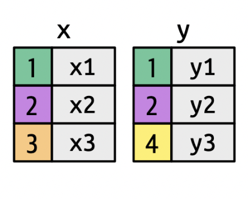

## `inner_join()`

Keeps observations when their keys are present in **both** datasets.

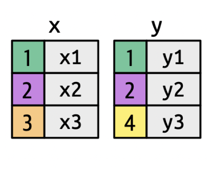

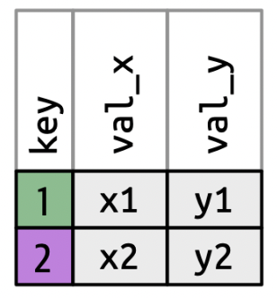

**Discussion**

When would you want to use `inner_join()`?

## `inner_join()`: IMDb Example

```r
directors_genres
```

| director_id | genre | prob |
| --- | --- | --- |
| 429 | Adventure | 0.750000 |
| 429 | Fantasy | 0.750000 |
| 2931 | Drama | 0.714286 |
| 2931 | Action | 0.428571 |
| 11652 | Sci-Fi | 0.500000 |
| 11652 | Action | 0.500000 |
| 14927 | Animation | 1.000000 |
| 14927 | Family | 1.000000 |
| 15092 | Comedy | 0.545455 |
| 15092 | Crime | 0.545455 |

```r
movies_directors
```

| director_id | movie_id |
| --- | --- |
| 429 | 300229 |
| 9247 | 124110 |
| 11652 | 10920 |
| 11652 | 333856 |
| 14927 | 192017 |
| 15092 | 109093 |
| 15092 | 237431 |

ID: 429, **2931**, 11652, 14927, 15092 ID: 429, **9247**, 11652, 14927, 15092

```r
inner_join(directors_genres, movies_directors,
           by = "director_id")
```

| director_id | genre | prob | movie_id |
| --- | --- | --- | --- |
| 429 | Adventure | 0.750000 | 300229 |
| 429 | Fantasy | 0.750000 | 300229 |
| 11652 | Sci-Fi | 0.500000 | 10920 |
| 11652 | Sci-Fi | 0.500000 | 333856 |
| 11652 | Action | 0.500000 | 10920 |
| 11652 | Action | 0.500000 | 333856 |
| 14927 | Animation | 1.000000 | 192017 |
| 14927 | Family | 1.000000 | 192017 |
| 15092 | Comedy | 0.545455 | 109093 |
| 15092 | Comedy | 0.545455 | 237431 |
| 15092 | Crime | 0.545455 | 109093 |
| 15092 | Crime | 0.545455 | 237431 |

ID: 429, **2931**, **9247**, 11652, 14927, 15092

## `inner_join()`: IMDb Example

What if our **key** does not have the same name?

```r
directors_genres
```

| director_id | genre | prob |
| --- | --- | --- |
| 429 | Adventure | 0.750000 |
| 429 | Fantasy | 0.750000 |
| 2931 | Drama | 0.714286 |
| 2931 | Action | 0.428571 |
| 11652 | Sci-Fi | 0.500000 |
| 11652 | Action | 0.500000 |
| 14927 | Animation | 1.000000 |
| 14927 | Family | 1.000000 |
| 15092 | Comedy | 0.545455 |
| 15092 | Crime | 0.545455 |

```r
directors
```

| id | first_name | last_name |
| --- | --- | --- |
| 429 | Andrew | Adamson |
| 9247 | Zach | Braff |
| 11652 | James (I) | Cameron |
| 14927 | Ron | Clements |
| 15092 | Ethan | Coen |

```r
inner_join(directors_genres,
           directors,
           by = join_by(director_id == id))
```

[output not shown]

Join by different variables on `dataX` and `dataY`: `join_by(a == b)` will match `dataX$a` to `dataY$b`.

## Piping Joins

Remember: the dataset you pipe in becomes the **first argument** of the function you are piping into!

- If you are using a pipe,
  - the piped in data is the **left** dataset
  - specify the **right** dataset inside the `join` function.

```r
inner_join(directors_genres, movies_directors)
```

…is equivalent to…

```r
directors_genres |>
  inner_join(movies_directors, by = "director_id")
```

## More Mutating Joins

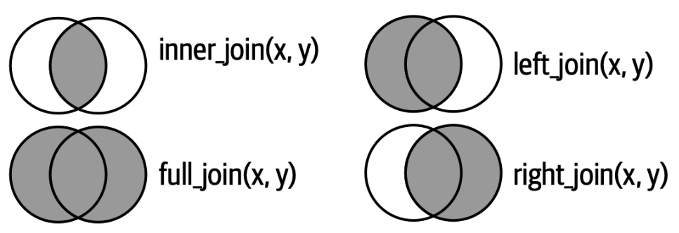

## Why Use a Certain Mutating Join?

- `inner_join()`
  - You want all of the columns from both left and right data and only to include the observations that have information in both
- `left_join()`
  - The left dataset is your “main” data and you just want to add information (columns) from the right dataset
- `right_join()`
  - The right data is your “main data” and you just want to add columns from the left dataset
- `full_join()`
  - You want all of the columns from both left and right data for all of the observations possible

## Filtering Joins: `semi_join()`

Keeps observations when their keys are present in **both** datasets, **but only keeps variables from the *left* dataset**.

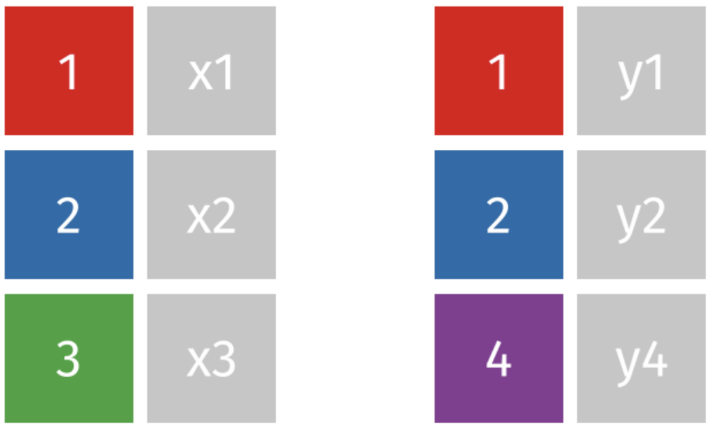

→

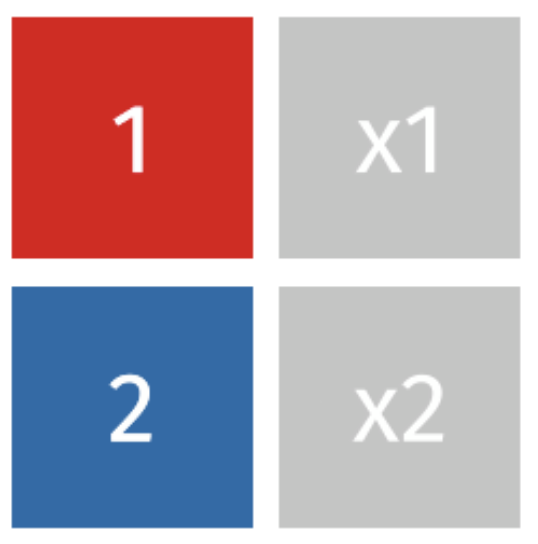

## IMDb Data Example

```r
directors_genres |>
  distinct(director_id)
```

| director_id |
| --- |
| 429 |
| 2931 |
| 11652 |
| 14927 |
| 15092 |

```r
movies_directors |>
  distinct(director_id)
```

| director_id |
| --- |
| 429 |
| 9247 |
| 11652 |
| 14927 |
| 15092 |

## Filtering Joins: `semi_join()`

- `semi_join()`
- Connection to `filter()`

```r
directors_genres |>
  semi_join(movies_directors)
```

| director_id | genre | prob |
| --- | --- | --- |
| 429 | Adventure | 0.750000 |
| 429 | Fantasy | 0.750000 |
| 11652 | Sci-Fi | 0.500000 |
| 11652 | Action | 0.500000 |
| 14927 | Animation | 1.000000 |
| 14927 | Family | 1.000000 |
| 15092 | Comedy | 0.545455 |
| 15092 | Crime | 0.545455 |

Movie Directors: 429, **2931**, 11652, 14927, 15092

```r
directors_genres |>
  filter(director_id %in% movies_directors$director_id)
```

| director_id | genre | prob |
| --- | --- | --- |
| 429 | Adventure | 0.750000 |
| 429 | Fantasy | 0.750000 |
| 11652 | Sci-Fi | 0.500000 |
| 11652 | Action | 0.500000 |
| 14927 | Animation | 1.000000 |
| 14927 | Family | 1.000000 |
| 15092 | Comedy | 0.545455 |
| 15092 | Crime | 0.545455 |

## Filtering Joins: `anti_join()`

**Removes** observations when their keys are present in **both** datasets, and **only keeps variables from the *left* dataset**.

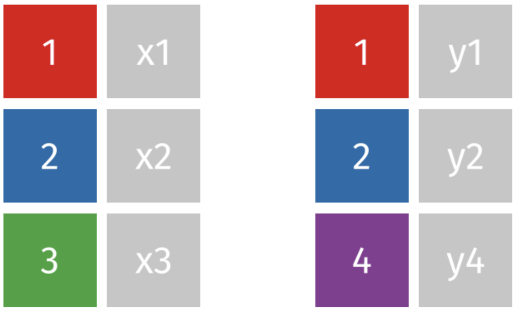

→

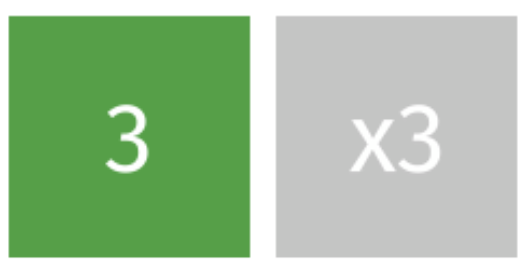

## Filtering Joins: `anti_join()`

- `anti_join()`
- Connection to `filter()`

```r
directors_genres |>
  anti_join(movies_directors)
```

| director_id | genre | prob |
| --- | --- | --- |
| 2931 | Drama | 0.714286 |
| 2931 | Action | 0.428571 |

Movie Directors: 429, **2931**, 11652, 14927, 15092

```r
directors_genres |>
  filter(!director_id %in% movies_directors$director_id)
```

| director_id | genre | prob |
| --- | --- | --- |
| 2931 | Drama | 0.714286 |
| 2931 | Action | 0.428571 |

## Building an Analytical Dataset

Now we have tools to:

- Combine multiple data sets (`xx_join()`)
- Subset to certain observations (`filter()` and `xx_join()`)
- Create new variables (`mutate()`)
- Select columns of interest (`select()`)

We are well on our way to building and cleaning up a nice dataset! 🥳

## Transform and Tidy

What’s next?

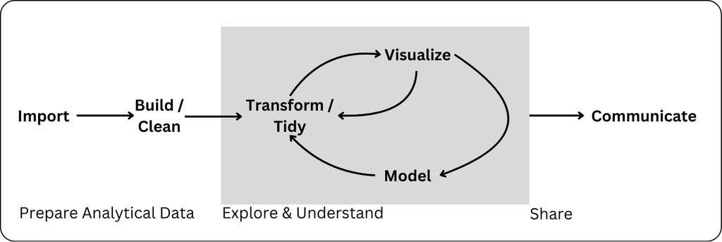

## Transform and Tidy

What’s next?

We may need to **transform** our data to turn it into the **version of tidy** that is best for a task at hand.

[figure not shown]

Allison Horst

# Reshaping Data Layouts with Pivots

## Creating Tidy Data

Let’s say we want to look at `mean` **cereal nutrients** based on `shelf`.

- The data are in a **wide** format – a separate column for each nutrient.

```r
library(liver)
data(cereal)
head(cereal)
```

| name | manuf | type | calories | protein | fat | sodium | fiber | carbo | sugars | potass | vitamins | shelf | weight | cups | rating |
| --- | --- | --- | --- | --- | --- | --- | --- | --- | --- | --- | --- | --- | --- | --- | --- |
| 100% Bran | N | cold | 70 | 4 | 1 | 130 | 10.0 | 5.0 | 6 | 280 | 25 | 3 | 1 | 0.33 | 68.40297 |
| 100% Natural Bran | Q | cold | 120 | 3 | 5 | 15 | 2.0 | 8.0 | 8 | 135 | 0 | 3 | 1 | 1.00 | 33.98368 |
| All-Bran | K | cold | 70 | 4 | 1 | 260 | 9.0 | 7.0 | 5 | 320 | 25 | 3 | 1 | 0.33 | 59.42551 |
| All-Bran with Extra Fiber | K | cold | 50 | 4 | 0 | 140 | 14.0 | 8.0 | 0 | 330 | 25 | 3 | 1 | 0.50 | 93.70491 |
| Almond Delight | R | cold | 110 | 2 | 2 | 200 | 1.0 | 14.0 | 8 | -1 | 25 | 3 | 1 | 0.75 | 34.38484 |
| Apple Cinnamon Cheerios | G | cold | 110 | 2 | 2 | 180 | 1.5 | 10.5 | 10 | 70 | 25 | 1 | 1 | 0.75 | 29.50954 |

## Creating Tidy Data

**Discussion**

How would we plot the mean cereal nutrients by shelf (as shown below) with the wide data using `ggplot2`?

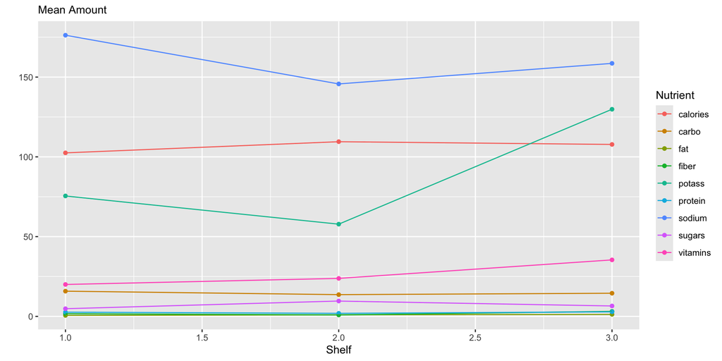

**Transforming** the data will make plotting **much** easier

## Creating Tidy Data

- Wide
- Wide Plot
- Long
- Long Plot

```r
cereal_wide <- cereal |>
  group_by(shelf) |>
  summarise(across(calories:vitamins, mean))
```

| shelf | calories | protein | fat | sodium | fiber | carbo | sugars | potass | vitamins |
| --- | --- | --- | --- | --- | --- | --- | --- | --- | --- |
| 1 | 102.5000 | 2.650000 | 0.60 | 176.2500 | 1.6850000 | 15.80000 | 4.800000 | 75.50000 | 20.00000 |
| 2 | 109.5238 | 1.904762 | 1.00 | 145.7143 | 0.9047619 | 13.61905 | 9.619048 | 57.80952 | 23.80952 |
| 3 | 107.7778 | 2.861111 | 1.25 | 158.6111 | 3.1388889 | 14.50000 | 6.527778 | 129.83333 | 35.41667 |

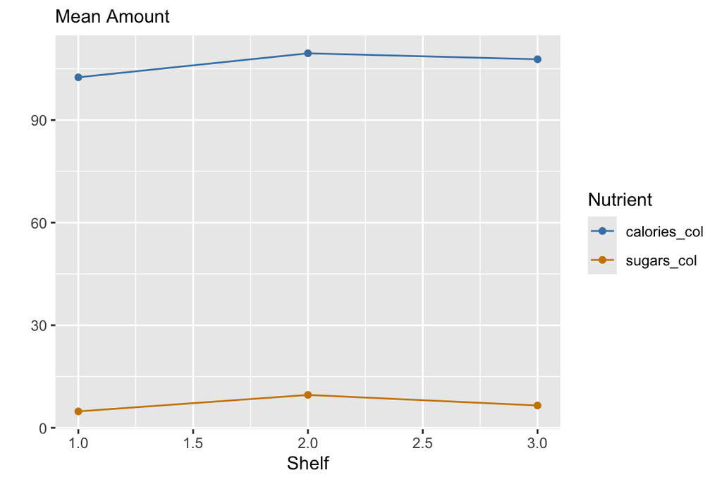

```r
my_colors <- c("calories_col" = "steelblue", "sugars_col" = "orange3")

cereal_wide |>
  ggplot() +
  geom_point(aes(x = shelf, y = calories, color = "calories_col")) +
  geom_line(aes(x = shelf, y = calories, color = "calories_col")) +
  geom_point(aes(x = shelf, y = sugars, color = "sugars_col")) +
  geom_line(aes(x = shelf, y = sugars, color = "sugars_col")) +
  scale_color_manual(values = my_colors, labels = names(my_colors)) +
  labs(x = "Shelf", y = "", subtitle = "Mean Amount", color = "Nutrient")
```

```r
cereal_long<- cereal |>
  pivot_longer(cols = calories:vitamins,
               names_to = "Nutrient",
               values_to = "Amount") |>
  group_by(shelf, Nutrient) |>
  summarise(mean_amount = mean(Amount))
```

| shelf | Nutrient | mean_amount |
| --- | --- | --- |
| 1 | calories | 102.5000000 |
| 1 | carbo | 15.8000000 |
| 1 | fat | 0.6000000 |
| 1 | fiber | 1.6850000 |
| 1 | potass | 75.5000000 |
| 1 | protein | 2.6500000 |
| 1 | sodium | 176.2500000 |
| 1 | sugars | 4.8000000 |
| 1 | vitamins | 20.0000000 |
| 2 | calories | 109.5238095 |
| 2 | carbo | 13.6190476 |
| 2 | fat | 1.0000000 |
| 2 | fiber | 0.9047619 |
| 2 | potass | 57.8095238 |
| 2 | protein | 1.9047619 |
| 2 | sodium | 145.7142857 |
| 2 | sugars | 9.6190476 |
| 2 | vitamins | 23.8095238 |
| 3 | calories | 107.7777778 |
| 3 | carbo | 14.5000000 |
| 3 | fat | 1.2500000 |
| 3 | fiber | 3.1388889 |
| 3 | potass | 129.8333333 |
| 3 | protein | 2.8611111 |
| 3 | sodium | 158.6111111 |
| 3 | sugars | 6.5277778 |
| 3 | vitamins | 35.4166667 |

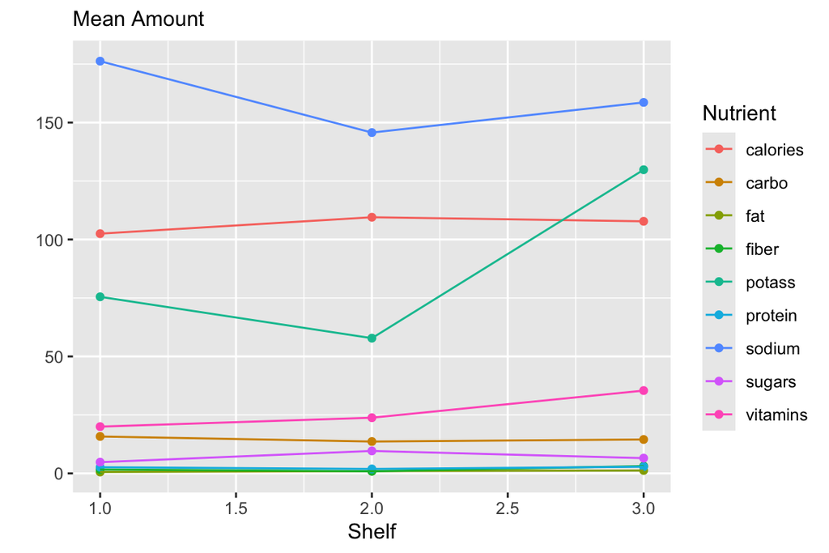

```r
cereal_long |>
  ggplot(aes(x = shelf,
             y = mean_amount,
             color = Nutrient)) +
  geom_point() +
  geom_line() +
  labs(x = "Shelf", y = "", subtitle = "Mean Amount")
```

## Data Layouts

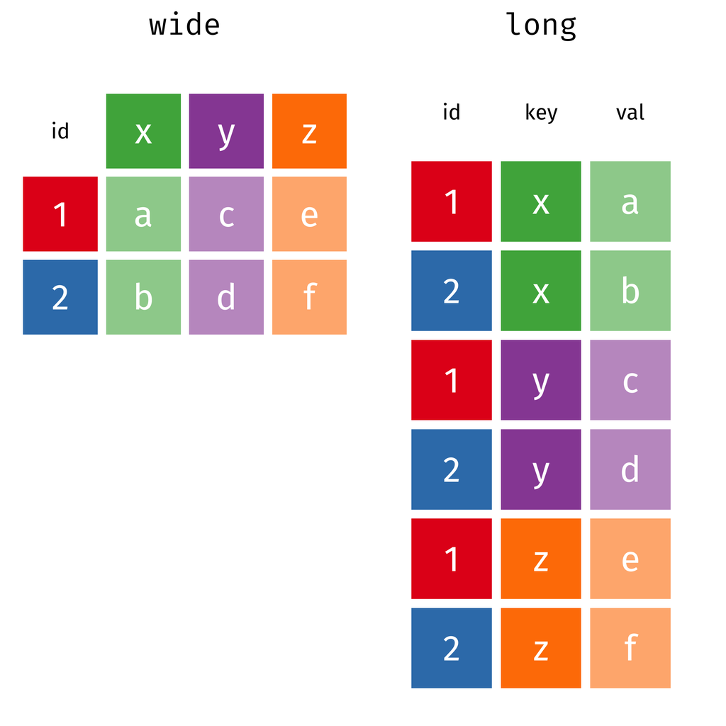

Kelsey Gonzalez

## Manual Method

Consider daily rainfall observed in SLO in January 2023.

- The data is in a human-friendly form (like a calendar).
- Each week has a row, and each day has a column.

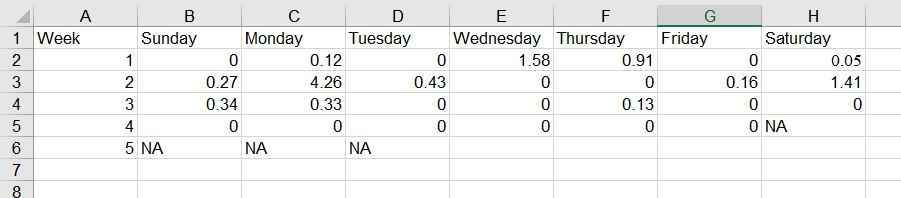

Data source

**Discussion**

How would you **manually** convert this to **long format**?

## Manual Method: Steps

0. Keep the column `Week`.
1. Create a new column `Day_of_Week`.
2. Create a new column `Rainfall` (hold daily rainfall values).
3. Now we have three columns – move Sunday values over.
4. Duplicate `Week` 1-5 and copy Monday values over.

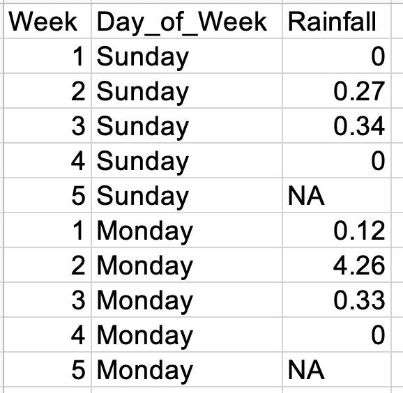

5. Repeat …

## Computational Approach

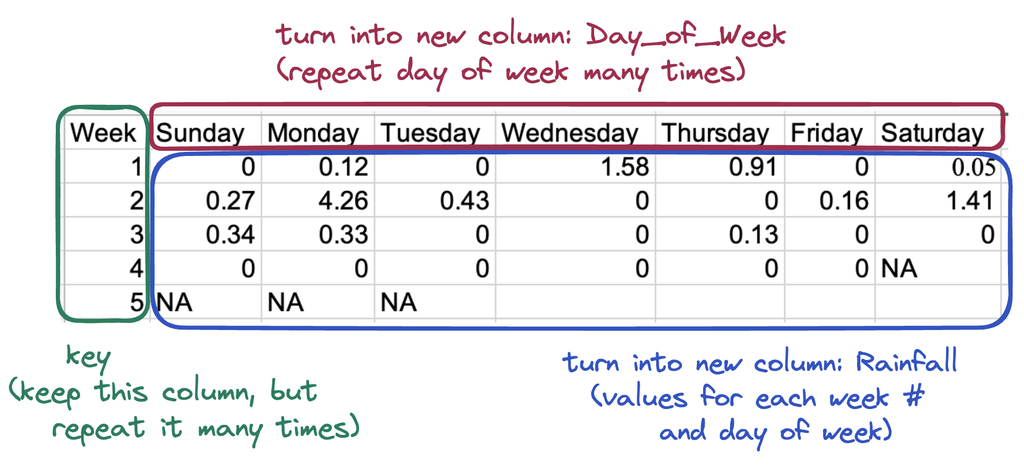

We can use `pivot_longer()` to turn a **wide** dataset into a **long(er)** dataset.

## `pivot_longer()`

Take a **wide** dataset and turn it into a **long** dataset.

- `cols` – specify the columns that should be pivoted.
  - Do **not** include the names of ID columns (columns to not be pivoted).
- `names_to` – the name of the new column containing the old column names.
- `values_to` – the name of the new column containing the old column values.

## `pivot_longer()`

```r
slo_rainfall |>
  pivot_longer(cols      = Sunday:Saturday,
               names_to  = "day_of_week",
               values_to = "rainfall")
```

| Week | day_of_week | rainfall |
| --- | --- | --- |
| 1 | Sunday | 0.00 |
| 1 | Monday | 0.12 |
| 1 | Tuesday | 0.00 |
| 1 | Wednesday | 1.58 |
| 1 | Thursday | 0.91 |
| 1 | Friday | 0.00 |
| 1 | Saturday | 0.05 |
| 2 | Sunday | 0.27 |
| 2 | Monday | 4.26 |
| 2 | Tuesday | 0.43 |
| 2 | Wednesday | 0.00 |
| 2 | Thursday | 0.00 |
| 2 | Friday | 0.16 |
| 2 | Saturday | 1.41 |
| 3 | Sunday | 0.34 |
| 3 | Monday | 0.33 |
| 3 | Tuesday | 0.00 |
| 3 | Wednesday | 0.00 |
| 3 | Thursday | 0.13 |
| 3 | Friday | 0.00 |
| 3 | Saturday | 0.00 |
| 4 | Sunday | 0.00 |
| 4 | Monday | 0.00 |
| 4 | Tuesday | 0.00 |
| 4 | Wednesday | 0.00 |
| 4 | Thursday | 0.00 |
| 4 | Friday | 0.00 |
| 4 | Saturday | NA |
| 5 | Sunday | NA |
| 5 | Monday | NA |
| 5 | Tuesday | NA |
| 5 | Wednesday | NA |
| 5 | Thursday | NA |
| 5 | Friday | NA |
| 5 | Saturday | NA |

## Long to Wide

What are the `mean` amount of `protein` for cereals on each `shelf` and for each `manuf`?

```r
mean_protein <- cereal |>
  group_by(manuf, shelf) |>
  summarize(mean_protein = mean(protein))
```

| manuf | shelf | mean_protein |
| --- | --- | --- |
| A | 2 | 4.000000 |
| G | 1 | 3.000000 |
| G | 2 | 1.285714 |
| G | 3 | 2.666667 |
| K | 1 | 2.750000 |
| K | 2 | 2.142857 |
| K | 3 | 2.916667 |
| N | 1 | 2.666667 |
| N | 2 | 2.500000 |
| N | 3 | 4.000000 |
| P | 1 | 1.500000 |
| P | 2 | 1.000000 |
| P | 3 | 3.000000 |
| Q | 1 | 5.000000 |
| Q | 2 | 2.000000 |
| Q | 3 | 2.500000 |
| R | 1 | 2.000000 |
| R | 3 | 3.000000 |

**Discussion**

What could we do to make this table easier to understand?

## `pivot_wider()`

Take a **long** dataset and turn it into a **wide** dataset.

- `id_cols` – specify the column(s) that contain the ID for unique rows in the wide dataset.
- `names_from` – the name of the column containing the new column names.
- `values_from` – the name of the column containing the new column values.

## `pivot_wider()`

Much easier to read!

```r
mean_protein |>
  arrange(shelf) |>
  pivot_wider(id_cols = manuf,
              names_from = shelf,
              values_from = mean_protein)
```

| manuf | 1 | 2 | 3 |
| --- | --- | --- | --- |
| G | 3.000000 | 1.285714 | 2.666667 |
| K | 2.750000 | 2.142857 | 2.916667 |
| N | 2.666667 | 2.500000 | 4.000000 |
| P | 1.500000 | 1.000000 | 3.000000 |
| Q | 5.000000 | 2.000000 | 2.500000 |
| R | 2.000000 | NA | 3.000000 |
| A | NA | 4.000000 | NA |

## Better names in `pivot_wider()`

Even better!

```r
mean_protein |>
  arrange(shelf) |>
  pivot_wider(id_cols = manuf,
              names_from = shelf,
              values_from = mean_protein,
              names_prefix = "shelf_")
```

| manuf | shelf_1 | shelf_2 | shelf_3 |
| --- | --- | --- | --- |
| G | 3.000000 | 1.285714 | 2.666667 |
| K | 2.750000 | 2.142857 | 2.916667 |
| N | 2.666667 | 2.500000 | 4.000000 |
| P | 1.500000 | 1.000000 | 3.000000 |
| Q | 5.000000 | 2.000000 | 2.500000 |
| R | 2.000000 | NA | 3.000000 |
| A | NA | 4.000000 | NA |

## PA 4: Military Spending

Today you will be tidying messy data to explore the relationship between countries of the world and military spending.

## Collaborative Protocol

During your collaboration, your group will alternate between three roles:

- Project Manager
- Computer
- Coder
- Reads out the prompt and ensures the group understands what is being asked.
- Manages resources (e.g., cheatsheets, textbook).
- Answers Coder’s questions about syntax based on the resources.
- Works with the group to debug the code.
- Encourages the Coder to vocalize and explain their thinking.
- Types the code specified by the Coder into the Quarto document.
- Runs the code provided by the Coder.
- Works with group to debug the code.
- Evaluates the output against the question prompt.
- Confirms they understand what the prompt is asking.
- Talks with the group about their ideas.
- Explains their thinking.
- Directs the Computer what to type.
- Works with the group to debug the code.

## Submission

- When you have completed the puzzle, you will submit the college on Canvas.
  - You can ask me if it is correct before you submit
- You do not need to submit your code, but you should check your code against the solutions when they are posted! . . .

**Starting Roles Today**

The person whose birthday is closest to today starts as the project manager, second as the computer.

## To do…

- **PA 4: Military Spending**
  - Due Tuesday 4/21 by 11:59pm
- - Reading and Review
- **Lab 4: California Childcare Costs**
  - Due Sunday 4/26 at 11:59 pm